# Homework 2 Solutions

Author: Matthew J. Crossley

Last update: 04 May, 2024

## Learning objectives

This homework will assess the following:

- Your ability to use `Python`, `numpy`, and `matplotlib`.
- Your ability to read and understand equations and translate / connect them to `Python` code.
- Your ability to use Euler’s method to approximate solutions to differential equations.

## Instructions

- Write a `.py` script that replicates each figure shown below **exactly**. When you are finished, submit your `.py` file through ilearn.

## 1

Use Euler’s method to find an approximate solution to the following differential equation:

$$\frac{d}{dt}x(t) = \beta_0 + \beta_1 x(t) + \beta_2 x^2(t) + \beta_3
x^3(t)\\
\beta_0 = .125\\
\beta_1 = -.2\\
\beta_2 = .09\\
\beta_3 = -.01$$

Use a time domain of $t \in [0, 100]$ and a time step of $\tau = 0.1$. Plot your result with $t$ on the x-axis and $x(t)$ on the y-axis (like the plot below).

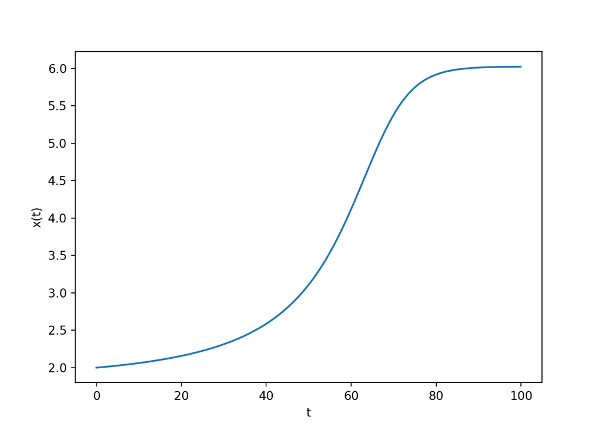

```python
import numpy as np
import matplotlib.pyplot as plt

T = 100
tau = 0.1
t = np.arange(0, T, tau)
n = t.shape[0]

x = np.zeros(n)
x[0] = 2

beta_0 = .125
beta_1 = -.2
beta_2 = .09
beta_3 = -.01

for i in range(1, n):
  dt = t[i] - t[i-1]
  dxdt = beta_0 + beta_1 * x[i-1] + beta_2 * x[i-1]**2 + beta_3 * x[i-1]**3
  x[i] = x[i-1] + dxdt * dt

fig, ax = plt.subplots(1, 1, squeeze=False)
ax[0, 0].plot(t, x)
ax[0, 0].set_xlabel('t')
ax[0, 0].set_ylabel('x(t)')
plt.show()
```

## 2

Use Euler’s method to find an approximate solution to the following differential equation:

$$\frac{d}{dt}x(t) = b - a x(t)$$

Use a time domain of $t \in [0, 100]$ and a time step of $\tau = 0.1$.

1. Plot your result with $t$ on the x-axis and $x(t)$ on the y-axis (like the plot below). Try to Find values for the time domain of your solution, $a$, $b$, and $x(0)$ that lead to a solution like this:

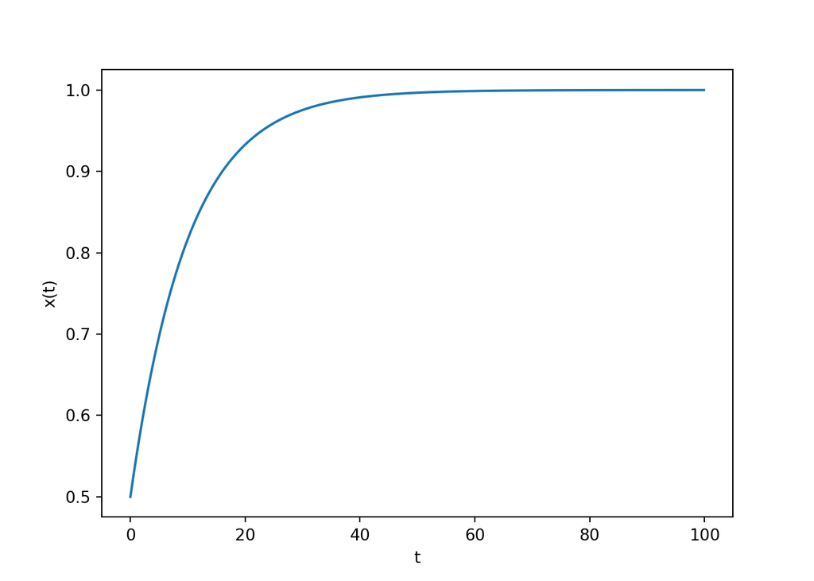

```python
import numpy as np
import matplotlib.pyplot as plt

T = 100
tau = 0.1
t = np.arange(0, T, tau)
n = t.shape[0]

x = np.zeros(n)
x[0] = 0.5
b = 0.1
a = 0.1

for i in range(1, n):
  dt = t[i] - t[i-1]
  dxdt = (b - a * x[i-1])
  x[i] = x[i-1] + dxdt * dt

fig, ax = plt.subplots(1, 1, squeeze=False)
ax[0, 0].plot(t, x)
ax[0, 0].set_xlabel('t')
ax[0, 0].set_ylabel('x(t)')
plt.show()
```

2. Add a reset condition to this dynamical system such that, $x(t)$ is manually reset to zero whenever $x(t) > 1$.

$$\frac{d}{dt}x(t) = b - a x(t) \\
\text{if } x(t) > 1, \text{then } x(t) \leftarrow 0$$

Plot your result with $t$ on the x-axis and $x(t)$ on the y-axis (like the plot below). Try to Find values for the time domain of your solution, $a$, $b$, and $x(0)$ that lead to a solution like this:

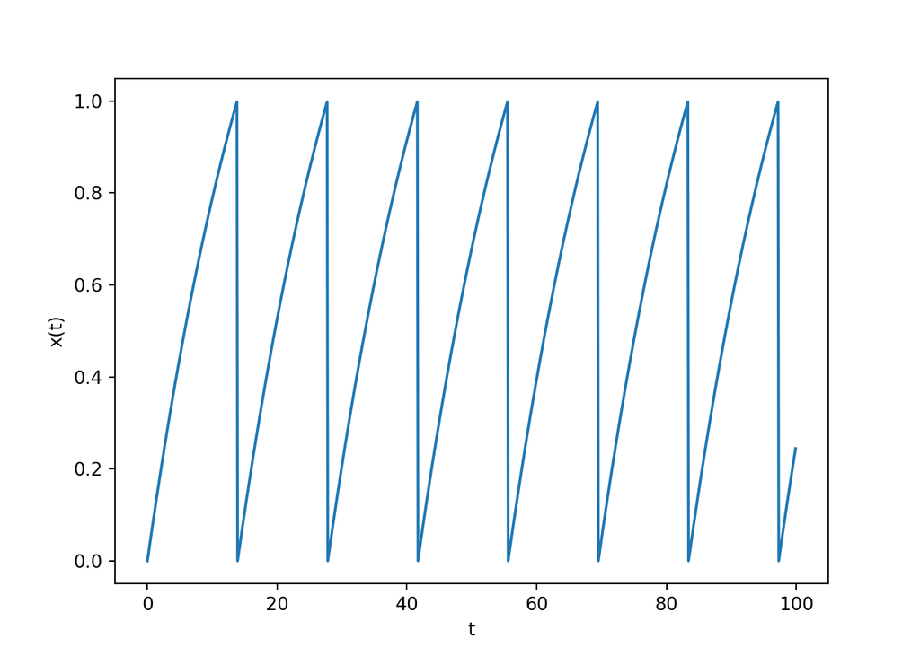

```python
import numpy as np
import matplotlib.pyplot as plt

T = 100
tau = 0.1
t = np.arange(0, T, tau)
n = t.shape[0]

x = np.zeros(n)
x[0] = 0.0
b = 0.1
a = 0.05

for i in range(1, n):
  dt = t[i] - t[i-1]
  dxdt = (b - a * x[i-1])
  x[i] = x[i-1] + dxdt * dt
  if x[i] > 1:
    x[i] = 0

fig, ax = plt.subplots(1, 1, squeeze=False)
ax[0, 0].plot(t, x)
ax[0, 0].set_xlabel('t')
ax[0, 0].set_ylabel('x(t)')
plt.show()
```

## 3

Use Euler’s method to find an approximate solution to the following differential equation:

$$\frac{d}{dt}x(t) = b + a x^2(t)$$

Use a time domain of $t \in [0, 100]$ and a time step of $\tau = 0.1$.

1. Plot your result with $t$ on the x-axis and $x(t)$ on the y-axis (like the plot below). Try to Find values for the time domain of your solution, $a$, $b$, and $x(0)$ that lead to a solution like this:

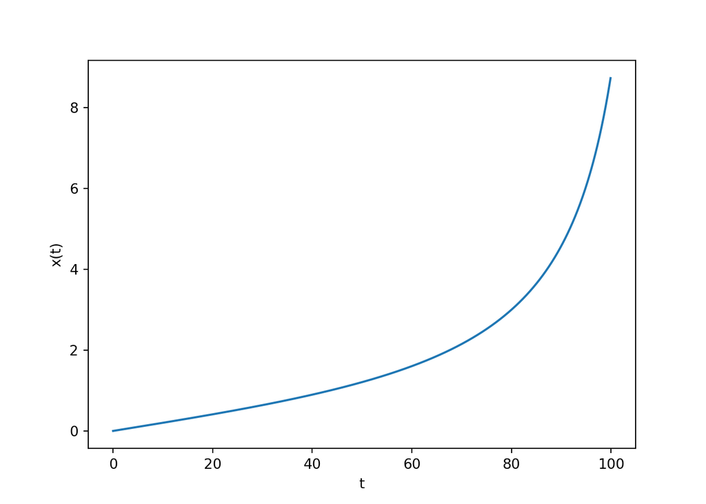

```python
import numpy as np
import matplotlib.pyplot as plt

T = 100
tau = 0.1
t = np.arange(0, T, tau)
n = t.shape[0]

x = np.zeros(n)
x[0] = 0.0
b = 2e-2
a = 1e-2

for i in range(1, n):
  dt = t[i] - t[i-1]
  dxdt = (b + a * x[i-1]**2)
  x[i] = x[i-1] + dxdt * dt

fig, ax = plt.subplots(1, 1, squeeze=False)
ax[0, 0].plot(t, x)
ax[0, 0].set_xlabel('t')
ax[0, 0].set_ylabel('x(t)')
plt.show()
```

2. Add a reset condition to this dynamical system such that, $x(t)$ is manually reset to zero whenever $x(t) > 1$.

$$\frac{d}{dt}x(t) = b + a x^2(t) \\
\text{if } x(t) > 1, \text{then } x(t) \leftarrow 0$$

Plot your result with $t$ on the x-axis and $x(t)$ on the y-axis (like the plot below). Try to Find values for the time domain of your solution, $a$, $b$, and $x(0)$ that lead to a solution like this:

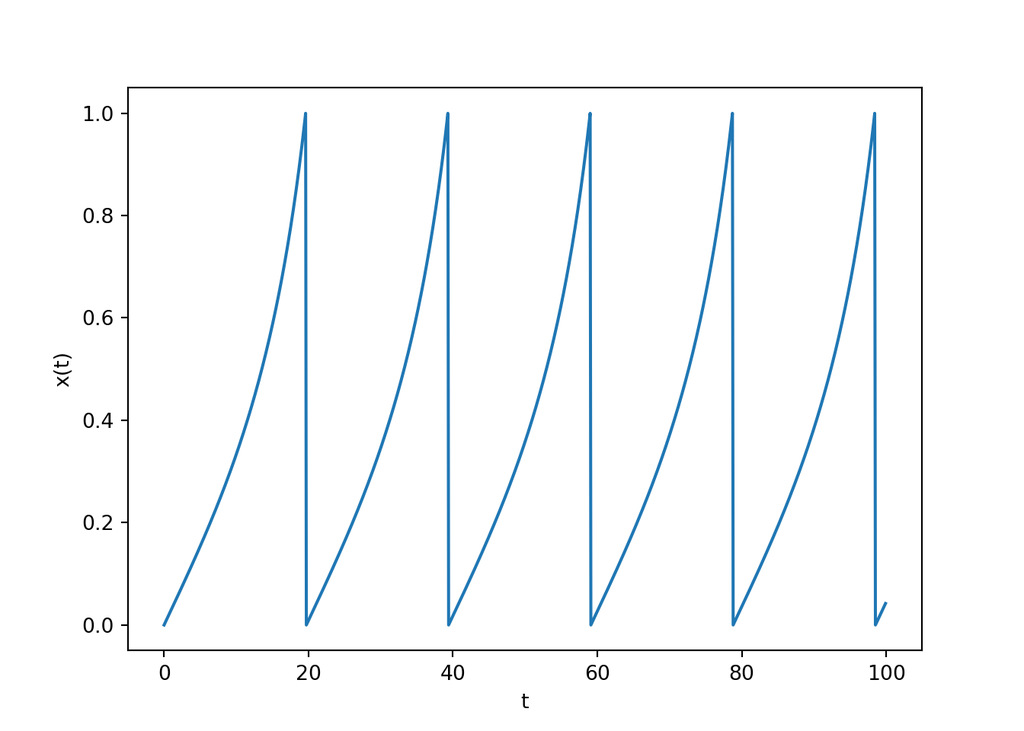

```python
import numpy as np
import matplotlib.pyplot as plt

T = 100
tau = 0.1
t = np.arange(0, T, tau)
n = t.shape[0]

x = np.zeros(n)
x[0] = 0.0
b = 3e-2
a = 1e-1

for i in range(1, n):
  dt = t[i] - t[i-1]
  dxdt = (b + a * x[i-1]**2)
  x[i] = x[i-1] + dxdt * dt
  if x[i] > 1:
    x[i] = 0

fig, ax = plt.subplots(1, 1, squeeze=False)
ax[0, 0].plot(t, x)
ax[0, 0].set_xlabel('t')
ax[0, 0].set_ylabel('x(t)')
plt.show()
```